# flexiSDM

## 10.1 Setup

The simulation uses a few extra packages—`SpFut.covariates` for downloading environmental layers, `rnaturalearth` for map data, and `sf` for spatial operations.

```r
library(SpFut.flexiSDM)
# remotes::install_git("https://code.usgs.gov/eastern-ecological-science-center/nearmi/SpFut-covariates.git")
library(SpFut.covariates)
library(rnaturalearth)
library(sf)
library(tidyverse)

set.seed(1)
```

## 10.2 Defining the region

We anchor the study area on real geography: the Great Salt Lake (GSL) and Salt Lake City (SLC). These are pulled from Natural Earth. The lake becomes the species’ core range, and the city is used later to place an urban survey dataset.

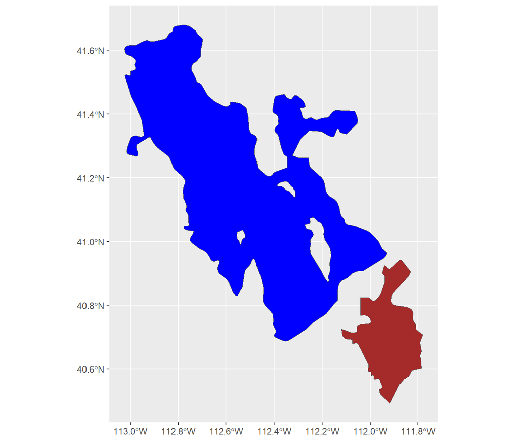

```r
# Great Salt Lake
GSL <- ne_download(scale = 10, type = "lakes",
                   category = "physical", returnclass = "sf") %>%
        filter(name == "Great Salt Lake")

# Salt Lake City point
slc_point <- ne_download(scale = 10, type = "populated_places",
                         category = "cultural", returnclass = "sf") %>%
              filter(NAME == "Salt Lake City")

# Salt Lake City outline: the urban area polygon that contains the SLC point
urban <- ne_download(scale = 10, type = "urban_areas",
                     category = "cultural", returnclass = "sf") %>%
          st_transform(st_crs(slc_point))
SLC <- urban[st_intersects(urban, slc_point, sparse = FALSE), ]

ggplot() +
  geom_sf(data = GSL, fill = "blue") +
  geom_sf(data = SLC, fill = "brown")
```

We buffer the lake by 100 km, then lay down a hexagonal grid. The hexagon size is computed from the target cell area (25 km²). Finally, `make_region()` packages the range, buffer, and grid into the `region` object.

```r
# use Great Salt Lake as starting area, add buffer
buffer <- 100000
gridstart <- GSL %>%
              st_transform(crs = 3857) %>%
              st_buffer(buffer)

# create grid
cellarea <- 25e6  # hexbins with 25km2 area -- smaller would raise runtime a lot
cellsize <- 2 * sqrt(cellarea/((3*sqrt(3)/2))) * sqrt(3)/2 # length across hexagon
conus.grid <- st_make_grid(gridstart, cellsize = cellsize, square = F) %>%
              st_as_sf() %>%
              rename(geometry = x) %>%
              mutate(conus.grid.id = 1:nrow(.))

# create region
region <- make_region(rangelist = list(lake = GSL),
                      buffer = buffer,
                      grid = conus.grid)
```

```
#> Removing small cells
#> Removing cells with <=1 neighbor...
```

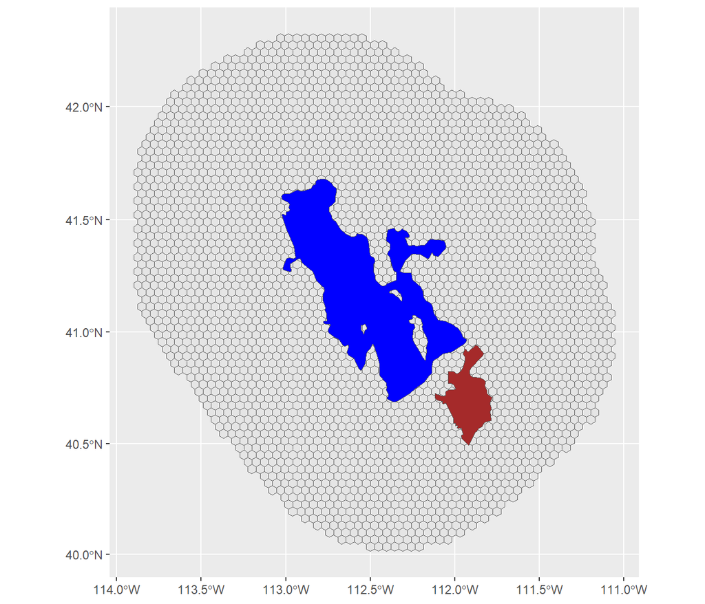

```r
ggplot() +
  geom_sf(data = region$sp.grid) +
  geom_sf(data = GSL, fill = "blue") +
  geom_sf(data = SLC, fill = "brown")
```

## 10.3 Building covariates

Real environmental layers (landcover, human footprint, elevation) are downloaded for each hexbin via the `SpFut.covariates` helpers. We keep wetland, water, elevation, footprint, and a south-facing indicator (`S`).

```r
land <- get_landcover(locs = region$sp.grid,
                      path = "TWS2026/data/",
                      id.label = "conus.grid.id")
footprint <- get_footprint(locs = region$sp.grid,
                           id.label = "conus.grid.id")
elev <- get_elevation(locs = region$sp.grid,
                      path = "TWS2026/data/",
                      id.label = "conus.grid.id")

# join covariates
covar <- full_join(land, footprint, by = "conus.grid.id") %>%
          full_join(elev, by = "conus.grid.id") %>%
          select(conus.grid.id, wetland, water, elevation, footprint, S) %>%
          rename(grid.id = conus.grid.id)
covar$wetland[which(covar$wetland > 0.5)] <- 0.5 # lower extreme wetland values to help model run better
```

Recall the modeling requirement that covariates be **scaled**. Here we save an unscaled copy, then scale all numeric columns with `scale_this()`—the same convention the fitting workflow expects.

```r
covar_unscaled <- covar

# scale numeric cols
numcols <- sapply(covar, is.numeric)
numcols <- which(numcols)
covar[,numcols] <- sapply(covar[,numcols], scale_this)

summary(covar)

# visualize covariates
covlabs <- data.frame(covariate = c("wetland", "elevation", "footprint", "S"),
                      Label = c("Wetland", "Elevation", "Footprint", "South-facing"))

plot_covar(rename(covar,
                  conus.grid.id = grid.id),
                  region,
                  cov.labs = covlabs,
                  scaled = T)$plot

cor_covar(rename(covar,
                 conus.grid.id = grid.id),
                 covlabs)$plot
```

[output not shown]

## 10.4 Simulating the true species

Now we define the “truth.” We choose a coefficient for each covariate—these are the values the fitted model will try to recover—and add the quadratic `elevation2` term. A small spatial field (`spat`) adds autocorrelated noise; dividing by 10,000 keeps it small relative to the covariate effects (`XB`).

```r
# Specify parameters
covs.z <- c("wetland", "footprint", "elevation", "elevation2", "S")
params <- c(0.46, -0.34, 0.27, -0.06, -0.21)
names(params) <- covs.z

# create quadratic term
covar <- covar %>%
          mutate(elevation2 = elevation * elevation) %>%
          select(all_of(c("grid.id", covs.z)))

# rename grid.id
grid <- region$sp.grid %>% rename(grid.id = conus.grid.id)

# create spatial noise
# we want this to be small compared to XB, so divide it by 10000
spat <- data.frame(grid.id = grid$grid.id,
                   spat = sim_cov(locs = grid, range = 100000)/10000)
summary(spat$spat)
```

[output not shown]

With parameters and spatial field in hand, `sim_species()` produces the true intensity surface, which we compare against later.

```r
# put together use list
use <- list(grid.sim = grid,
            grid.inf = grid,
            covar = covar,
            param = params,
            spat = spat)

# simulate species!
sp <- sim_species(use = use)

map_species_data(title = "Simulated species",
                 plot  = "true",
                 sim   = sp)$plot

summary(sp$true$intensity)
```

[output not shown]

## 10.5 Simulating the datasets

From one true distribution we draw **four datasets of different types and with different biases**.

### 10.5.1 iNat (presence-only)

Presence-only data mimic opportunistic citizen-science records. We build an `effort` surface that is loosely correlated with human footprint plus noise, then `sim_POdat()` generates presences where both the species and observer effort are high.

```r
# Create effort metric - slightly correlated with human footprint but lots of noise
effort <- (sim_cov(locs = grid, range = 10) + footprint$footprint/10)

ggplot(grid) +
  geom_sf(aes(fill = effort))

# create use list
covar.eff <- data.frame(grid.id = grid$grid.id,
                        effort = scale(effort))
param <- c("effort" = 3.06)

use <- list(covar = covar.eff, param = param, alpha = 0.01)

# simulate
start <- Sys.time()
inat <- sim_POdat(true      = sp,
                  use       = use,
                  cell.area = 0.005)

Sys.time() - start
nrow(inat$dat)
```

[output not shown]

### 10.5.2 Northern Salt Lake Beast Brigade (detection/non-detection)

A structured survey covering only the **northern** part of the region (above 41.2° latitude). We crop to that area, place 100 random sites, and `sim_surveydat()` generates detection/non-detection records. Note the restricted spatial extent—this is a deliberate bias the integrated model must handle.

```r
# start with GSL, add buffer, then crop to above 41.2 lat
buffGSL <- GSL %>%
  st_transform(3857) %>% st_buffer(80000) %>%
  st_transform(4326)

cropbb <- buffGSL %>% st_bbox()
cropbb["ymin"] <- 41.2
northGSL <- st_crop(buffGSL, cropbb)

# find grid cells in that region
northGSLgrid <- st_intersection(st_transform(region$sp.grid, 4326), northGSL) %>%
                select(conus.grid.id, geometry) %>%
                rename(grid.id = conus.grid.id)

# create locations within that region
locs <- sim_survey_sites(grid = st_transform(northGSLgrid, 3857),
                         method = "random", nsite = 100, nvisit = 1)

# visualize
ggplot() +
  geom_sf(data = region$sp.grid, aes(fill = sp$true$intensity,
                                     color = sp$true$intensity)) +
  geom_sf(data = northGSLgrid, fill = NA, color = "white") +
  geom_sf(data = northGSL, fill = NA, color = "red") +
  geom_sf(data = locs, color = "green")

# create use list
use <- list(locs = locs)

# simulate
NSLBB <- sim_surveydat(true      = sp,
                       use       = use,
                       survey.type = "DND",
                       covFormSite = "linear",
                       covFormVisit = "")
```

[output not shown]

### 10.5.3 Utah Mythical Creature Count (count)

A count survey on a **regular** grid of 50 sites within Utah (below 42° latitude). Counts carry more information than detection/non-detection, but coverage is spatially limited and the sites are very spread out.

```r
grid1 <- region$region %>% st_transform(crs = 4326)
cropbb <- grid1 %>% st_bbox()
cropbb["ymax"] <- 42

grid1 <- st_crop(grid1, cropbb) %>%
          st_intersection(st_transform(region$sp.grid, 4326),
                          region$sp.grid) %>%
          select(conus.grid.id, geometry) %>%
          rename(grid.id = conus.grid.id)

locs <- sim_survey_sites(grid = st_transform(grid1, 3857),
                         method = "regular", nsite = 50, nvisit = 1)

use <- list(locs = locs)

UMCC <- sim_surveydat(use = use,
                      true      = sp,
                      survey.type = "count",
                      covFormSite = "linear",
                      covFormVisit = "")
```

### 10.5.4 SLC Biodiversity Survey (count, repeated visits)

An intensive local survey near Salt Lake City: only 20 sites, but each visited **10 times**. Repeated visits let the model separate detection probability from true abundance—rich information over a tiny footprint.

```r
# start with SLC, add buffer
SLCgrid <- SLC %>%
            st_transform(3857) %>% st_buffer(10000) %>%
            st_transform(4326) %>%
            st_intersection(st_transform(region$sp.grid, 4326)) %>%
            select(conus.grid.id, geometry) %>%
            rename(grid.id = conus.grid.id)

# create use list
locs <- sim_survey_sites(grid = st_transform(SLCgrid, 3857),
                         method = "random", nsite = 20, nvisit = 10)

use <- list(locs = locs)

# simulate
SLCBS <- sim_surveydat(true         = sp,
                       use          = use,
                       survey.type  = "count",
                       covFormSite  = "linear",
                       covFormVisit = "",
                       link         = "logit")
```

> **Check your understanding.** Each dataset trades off coverage against information content: iNat is broad but biased, NSLBB and UMCC are structured but spatially restricted, and SLCBS is information-rich but tiny. No single one sees the whole picture, which is why integrating them is critical.

## 10.6 Formatting and saving

```r
datalist <- list(PO_iNat = inat,
                 DND_NSLBB = NSLBB,
                 count_UMCC = UMCC,
                 count_SLCBS = SLCBS)
sim_out <- format_sim(true = sp,
                      data = datalist)

region       <- sim_out$region
species.data <- sim_out$species.data
covar        <- sim_out$covar

# Add effort covariates for PO to covar
covar <- full_join(covar, datalist$PO_iNat$covar, by = c("conus.grid.id" = "grid.id"))


pl <- map_species_data(title = "Simulated data",
                       region = region,
                       plot = "samples",
                       sim = T,
                       details = T,
                       species.data = species.data,
                       inat.agg = FALSE,
                       plot.range = FALSE,
                       plot.region = TRUE,
                       subtitle = FALSE)$plot

pl <- map_species_data(title = "True distribution",
                       region = region,
                       plot = "true",
                       sim = sp)$plot

true <- sp
# true$covForm <- NULL # remove covForm so that it works with flexiSDM v1.1.1

save(region, datalist, species.data, covar, true,
     file = "TWS2026/data/data.RData")
```